# Submitted data error checks

# 0. Instructions for submitters

Submitters should use this file to check for problems with submitted data. Send either a list of problems or confirmation that everything looks OK to Sasha by email. Be sure to reference the dataset version and file creation date/time when doing so. These are:

```
## Version:  2.70
```

```
## [1] "Date/time: 2025-12-15 11:28:01.049486"
```

Each of these html files contains a summary of the data from a single submitted spreadsheet file. The html name is based on the name of the submitted file. Use the details below to check:

- Institute abbreviation, submitter and contributor names
- The plot location(s), using the map zoom and pan features if needed
- For problems in the first sections; “OK” means there are no problems in a particular section, “warning” is something that should be checked (but might be OK), “error” is a problem that needs to be addressed
- For numeric values outside the expected range in the “Value checks” section
- Variables with missing values–are there any missing that you thought you included?
- Plots of flux, cumulative emission over time, and final cumulative emission for strange patterns, unexpectedly high or low values
- Plots of weather data for appropriate differences between plots and expected diurnal or other patterns
- Plots of manure and application data for correct values

Finally, the numeric summary at the end might provide details that can help in pinpointing problems, but typically does not need to be checked.

# 1. Submitter

| inst.abbrev | submitter | version | date |
| --- | --- | --- | --- |
| AU | Dela Pierre, Flavia | 1 | 2025-12-11 |

# 2. Contributors

| contributor | institute |
| --- | --- |
| Støckler, Anna Holm | Aarhus University |
| Pedersen, Johanna | Aarhus University |
| Dela Pierre, Flavia | Aarhus University |
| Kamp, Jesper Nørlem | Aarhus University |
| Feilberg, Anders | Aarhus University |

# 3. File and directory names

```
## [1] "../../data-submitted/03/AU"
```

```
## [1] "../../data-submitted/03/AU/ALFAM2_template_8.3_Stabil26.xlsx"
```

# 4. Location

[interactive chart not shown]

# 5.Keys and codes

## Codes in Treatments sheet

```
## OK
```

```
## OK
```

## Codes in Plots sheet

```
## OK
```

```
## OK
```

## Codes in Emission sheet

```
## OK
```

```
## OK
```

## Code merge check (matching project, experiment, field, plot, treatment)

```
## OK
```

```
## OK
```

```
## OK
```

```
## OK
```

```
## OK
```

# 6. Publication info

## Check for missing codes

```
## OK
```

```
## OK
```

## Complete citations given

```
## OK
```

```
## OK
```

# 7. Emission sheet

## Duplicated intervals

```
## OK
```

## Missing incorporation time

```
## OK
```

## Delay after application

```
## OK
```

## Missing or double interval number

```
## OK
## OK
## OK
## OK
## OK
## OK
## OK
## OK
## OK
## OK
## OK
## OK
## OK
## OK
## OK
## OK
## OK
## OK
## OK
## OK
## OK
## OK
## OK
## OK
## OK
## OK
## OK
## OK
## OK
## OK
## OK
## OK
## OK
## OK
## OK
## OK
## OK
## OK
## OK
## OK
```

[output cut: 22 more lines]

```
## OK
## OK
## OK
## OK
## OK
## OK
## OK
## OK
## OK
## OK
## OK
## OK
## OK
## OK
## OK
```

## Missing time between intervals

```
## OK
## OK
## OK
## OK
## OK
## OK
## OK
## OK
## OK
## OK
## OK
## OK
## OK
## OK
## OK
## OK
## OK
## OK
## OK
## OK
## OK
## OK
## OK
## OK
## OK
## OK
## OK
## OK
## OK
## OK
## OK
## OK
## OK
## OK
## OK
## OK
## OK
## OK
## OK
## OK
```

[output cut: 23 more lines]

```
## OK
## OK
## OK
## OK
## [1] "Problem, see following rows (compare start time to end time in previous rows):"
## [1] 5139
## OK
## OK
## OK
## OK
## OK
## OK
## OK
## OK
## OK
```

## Measurement method and units

Measurement technique:

| Method | Frequency |
| --- | --- |
| Wind tunnel | 5927 |

Measurement technique classification:

| Classification | Frequency |
| --- | --- |
| wt | 5927 |

Emission units and conversion factors.

| Original unit | Conversion factor applied | Final unit |
| --- | --- | --- |
| kg N/ha-hr | 1 | kg N/ha-hr |

# 7. Value checks

Check to see if submitted values are within a reasonable range.

## Weather

```
## wind : OK
## rain.rate : OK
## air.temp : OK
## soil.temp : OK
## soil.temp.surf : No values to check.
## air.temp.z : OK
## wind.z : OK
```

## Manure and application

```
## man.stor : No values to check.
## man.dm : Some values out of range
## [1] "18.64" "6.82"
## man.vs : Some values out of range
## [1] "57.32" "92.8"
## man.tkn : Some values out of range
## [1] "1.32" "9.28"
## man.tan : OK
## man.tic : No values to check.
## man.ua : No values to check.
## man.vfa : No values to check.
## man.ph : OK
## app.rate : OK
## crop.z : No values to check.
```

## Emission

```
## j.NH3 : OK
## e.int : OK
## e.rel : Some values out of range
## [1] -0.09098659  1.28792989
```

# 8. Missing values

Check for missing values.

## All variables

```
## Some values missing:
## Table below has number of missing observations by variable:
##         pub.id  meas.tech.det             oc      soil.type   soil.water.v
##           5927           5927           5927           5927           5927
##     soil.moist           till        man.bed       man.trt2       man.trt3
##           5927           5927           5927           1989           4711
##       man.stor        man.tic         man.ua        man.vfa         incorp
##           5927           5927           5927           5927           5927
##    time.incorp       man.area       dist.inj       furrow.z       furrow.w
##           5927           5927           5927           5927           5927
##           crop         crop.z      crop.area            lai     notes.plot
##           5927           5927           5927           5927           5810
##          bg.dl        pH.surf soil.temp.surf           wind            MOL
##           5927           5927           5927           2611           5927
##          ustar             rl       wind.loc        far.loc        wind.2m
##           5927           5927           5927           5927           2611
##       pub.info     soil.type2         exper2           rep2      crop.orig
##           5927           5927           5927           5927           5927
##    incorp.orig
##           5927
```

## Application method and measurement method

```
## OK
```

```
## OK
```

# 9. Plots

## Calculated cumulative emission

Cumulative emission. Missing values imputed (linear interpolation). Numeric labels show position of data in data file: row in the “Plots” sheet and first row in the “Emission” sheet. Labels in center of the first plot have measurement method, manure source, and application method. The same emission data are plotted a few different ways to facilitate checking for problems, e.g., comparing plot to each other or checking application dates. The same colors should be be used for particular field plots throughout this section.

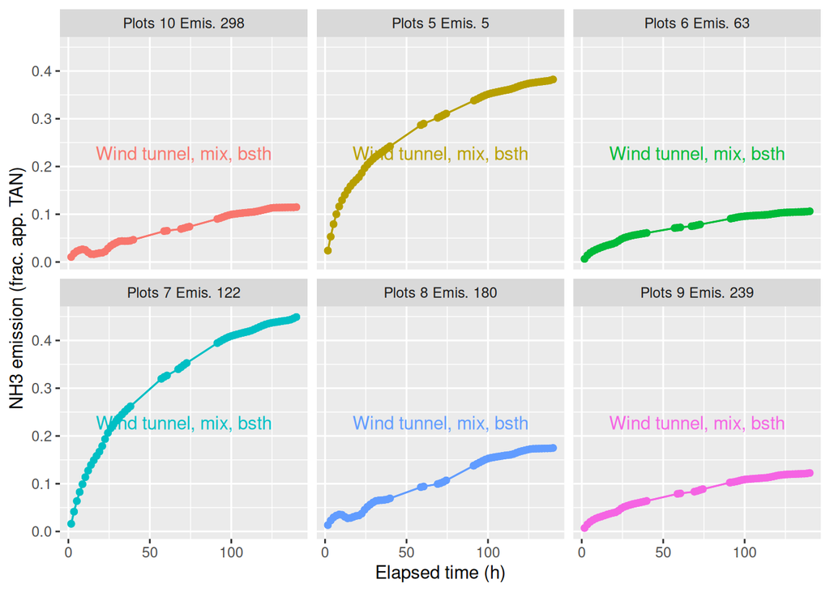

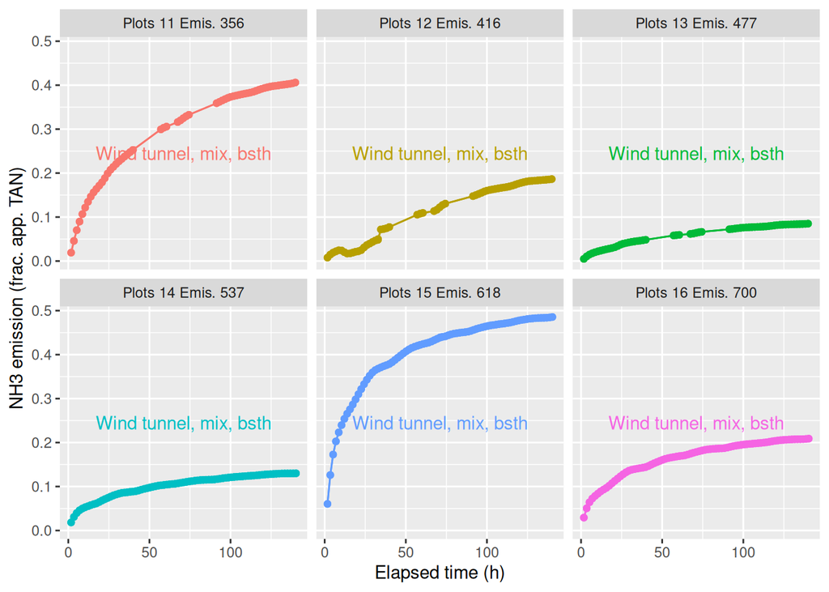

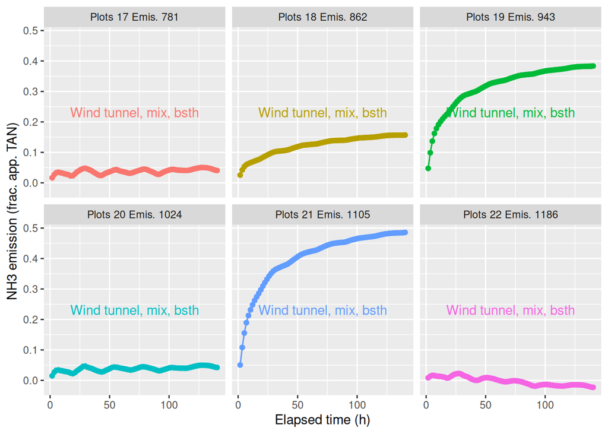

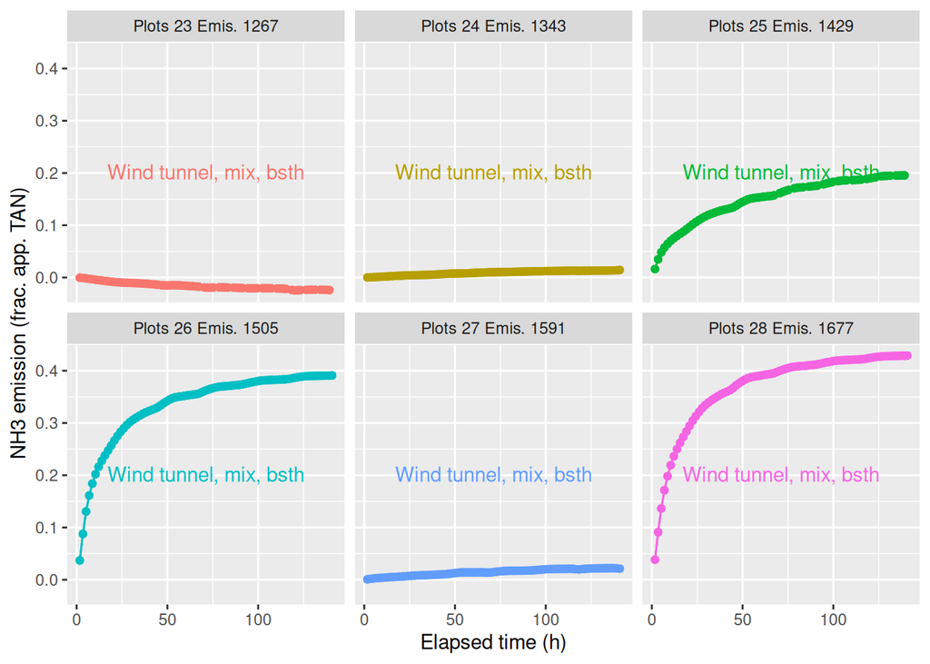

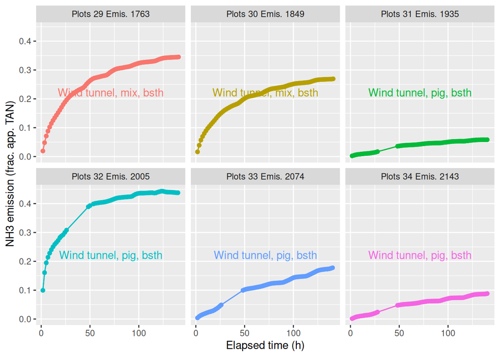

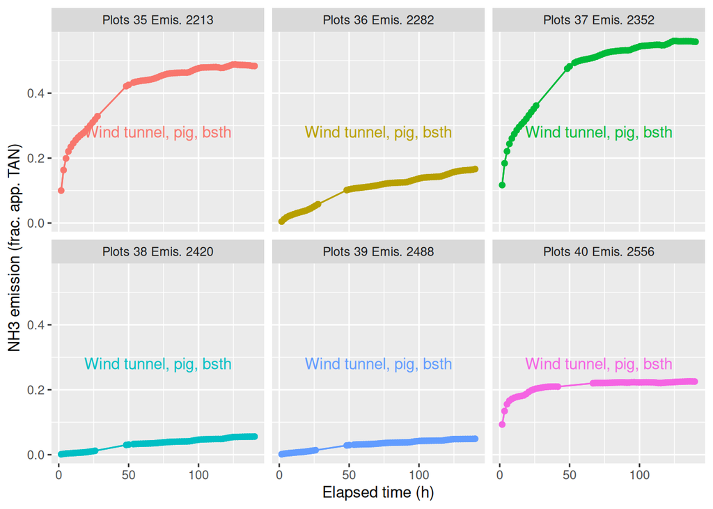

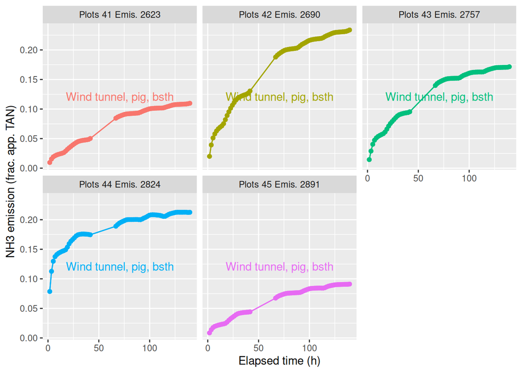

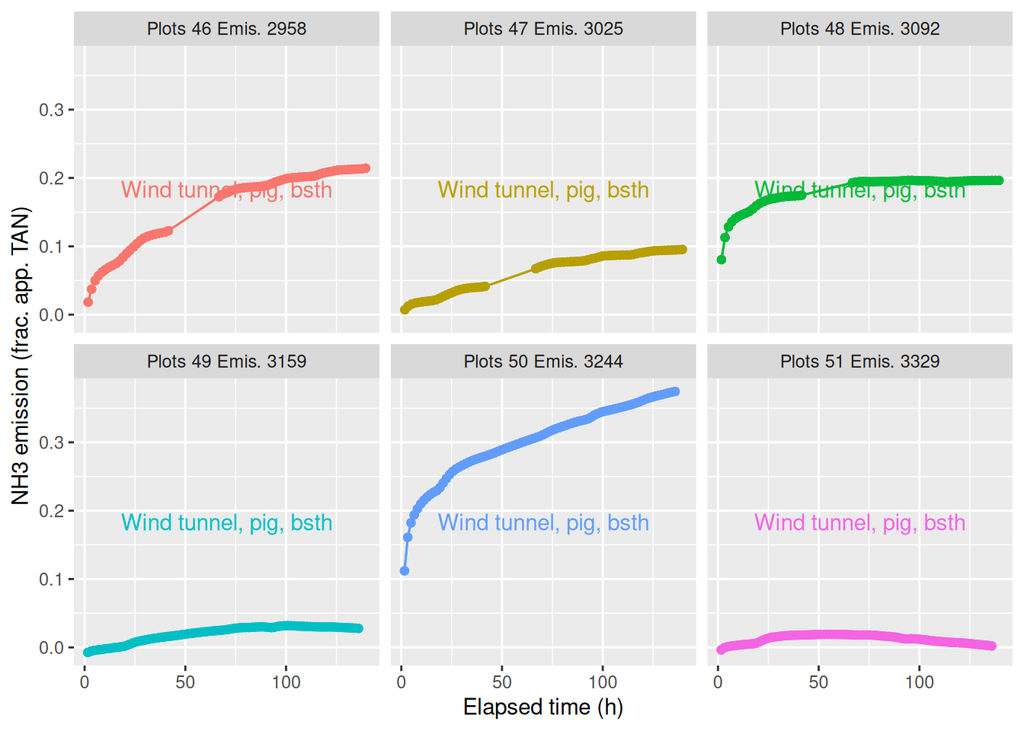

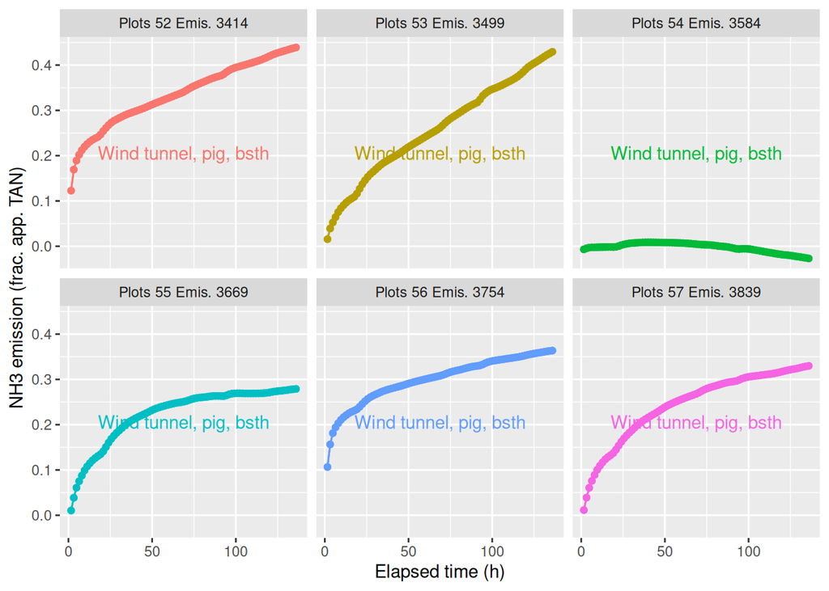

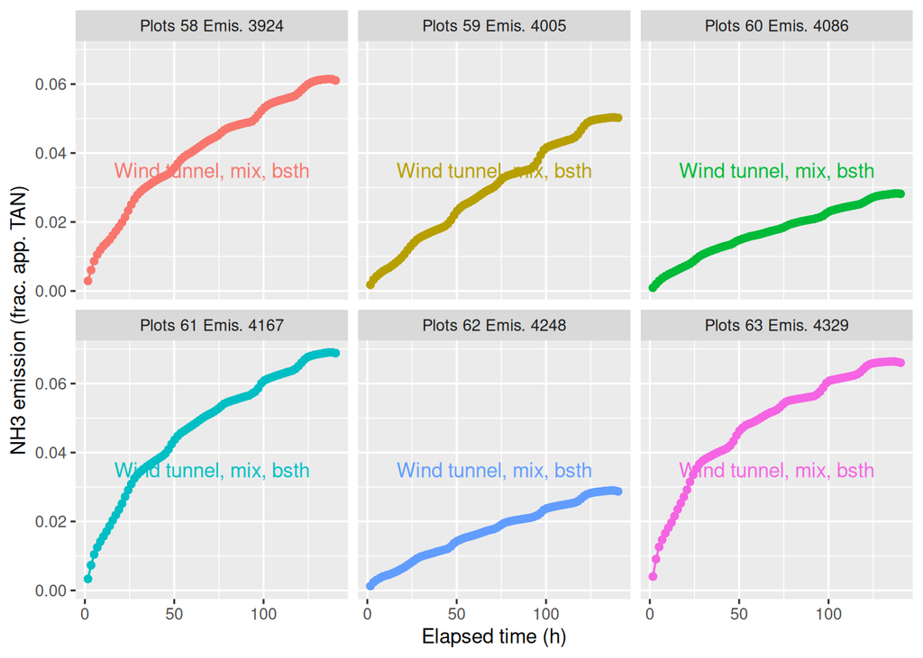

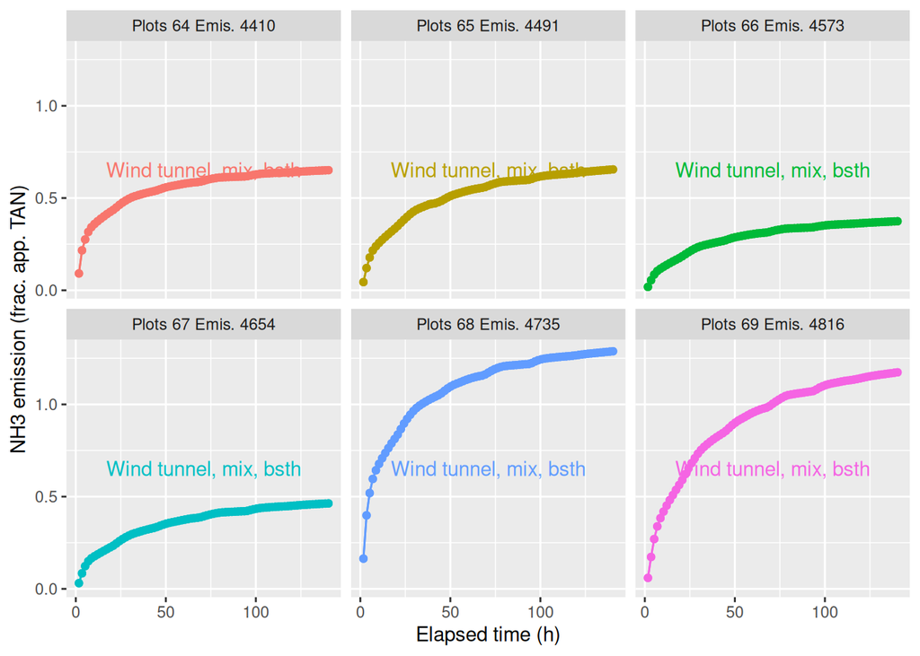

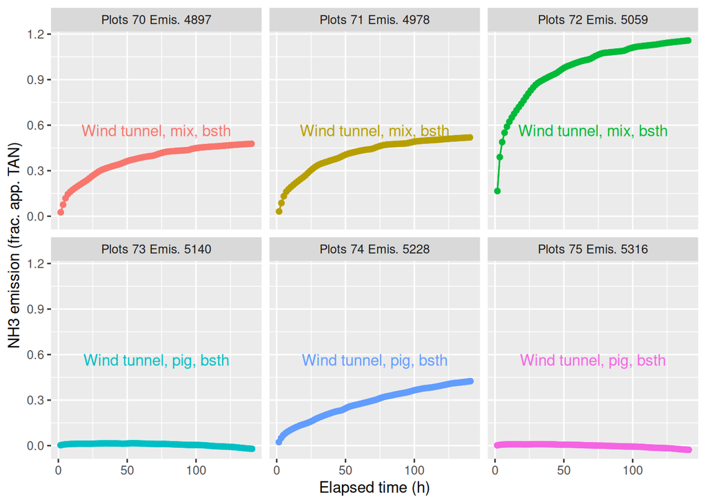

[1 more figures not shown]

## Final cumulative emission

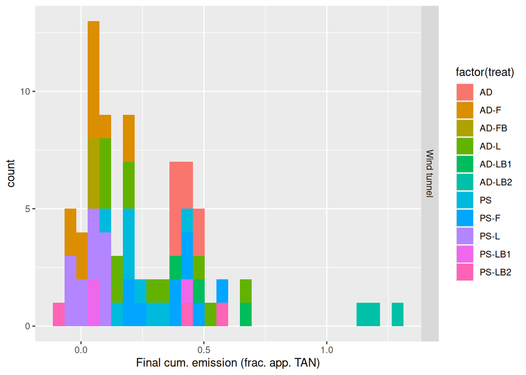

## Relative versus absolute emission

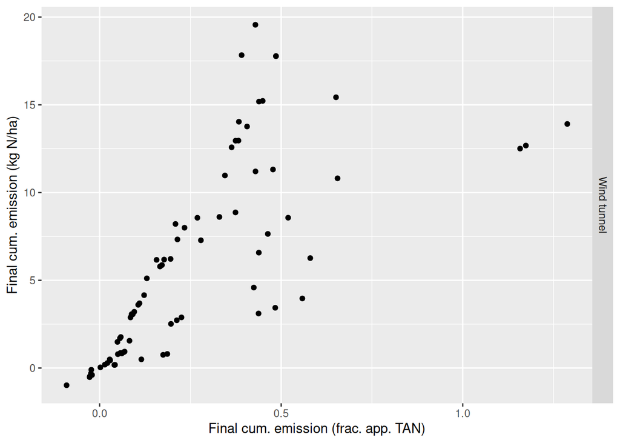

## Flux

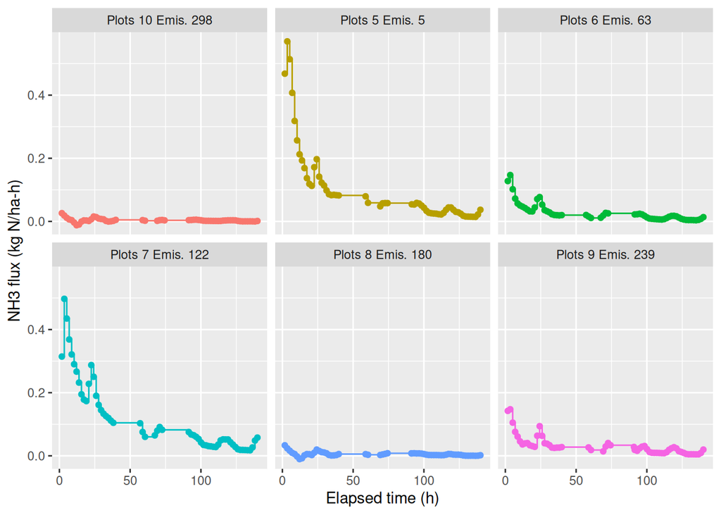

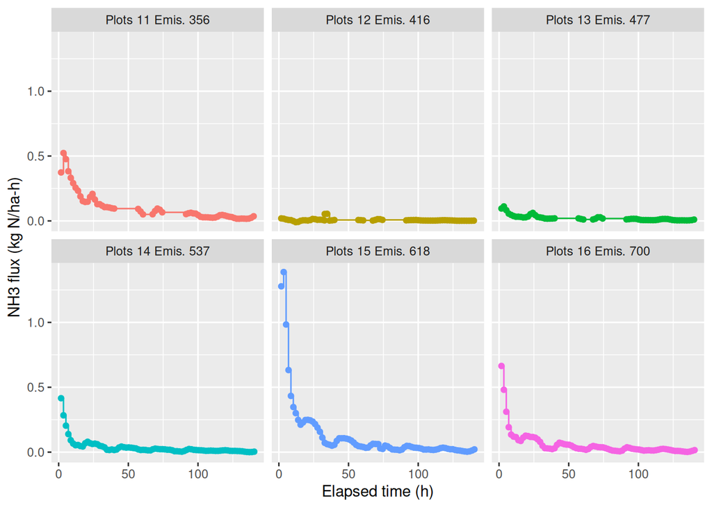

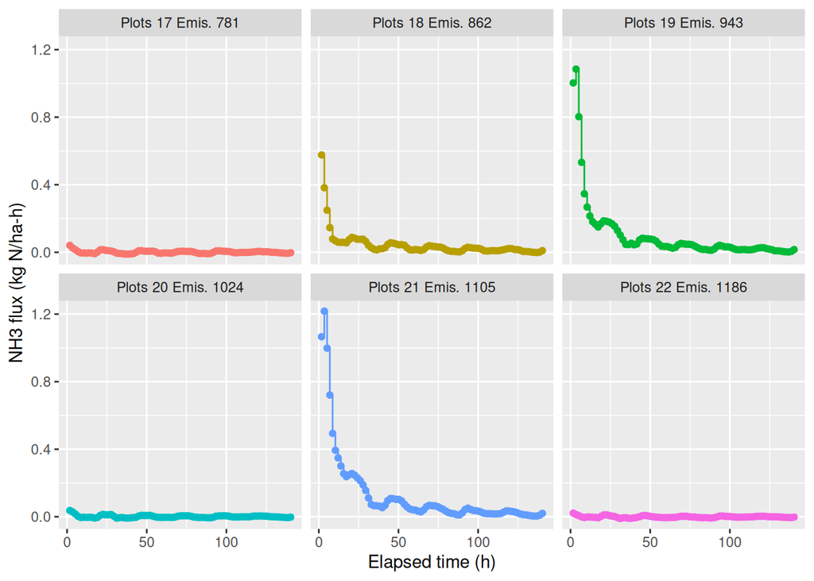

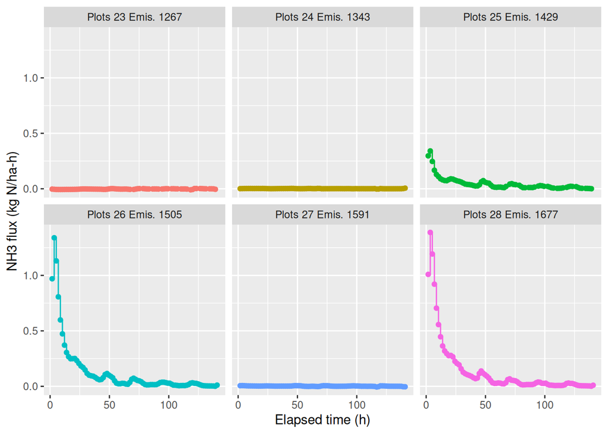

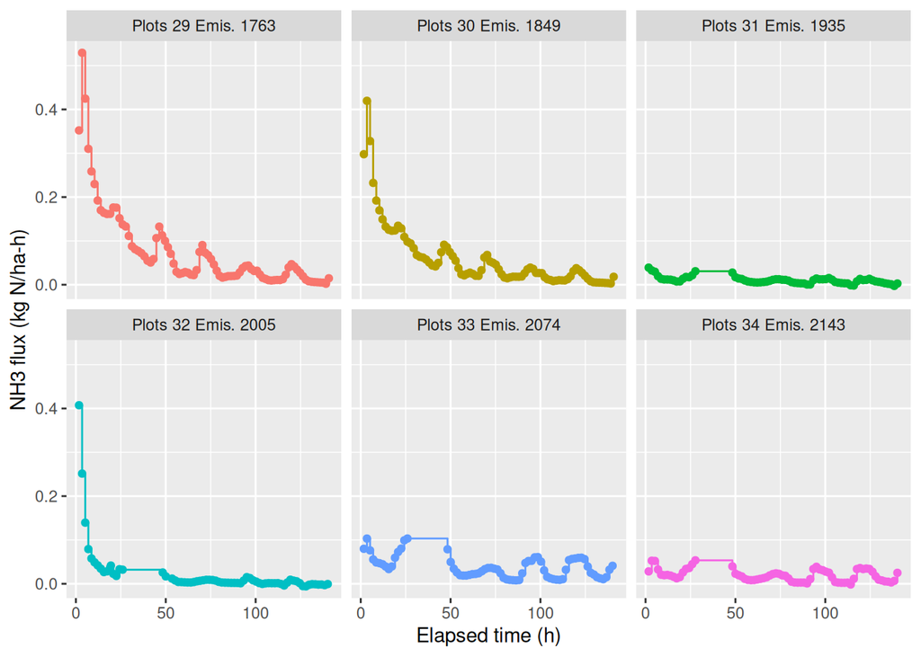

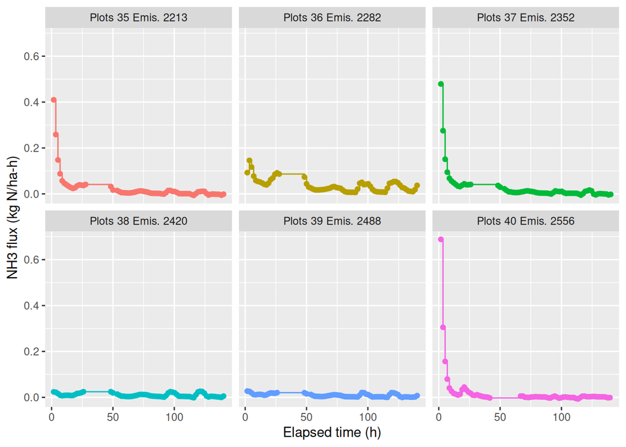

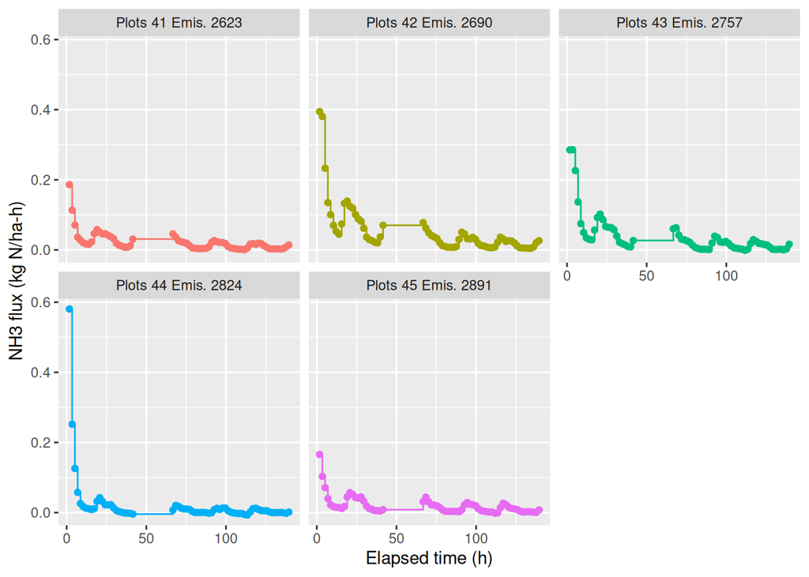

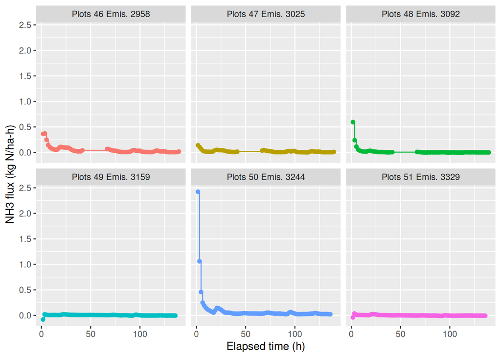

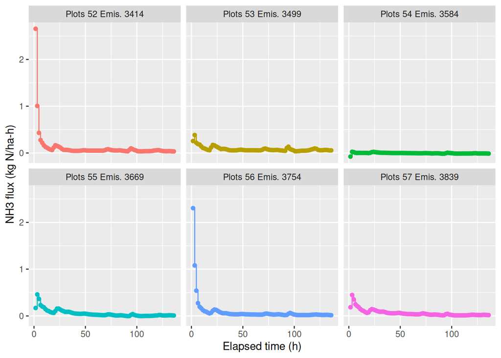

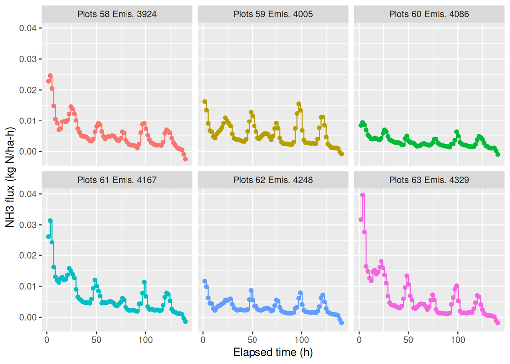

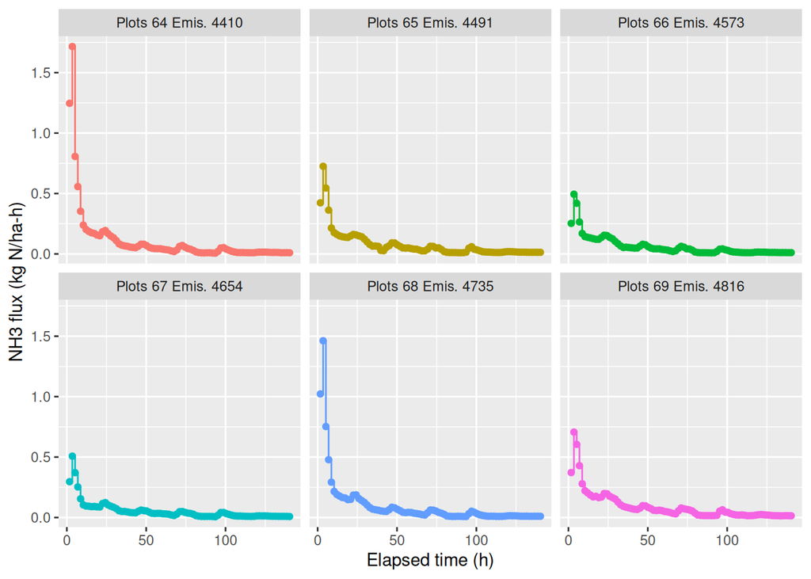

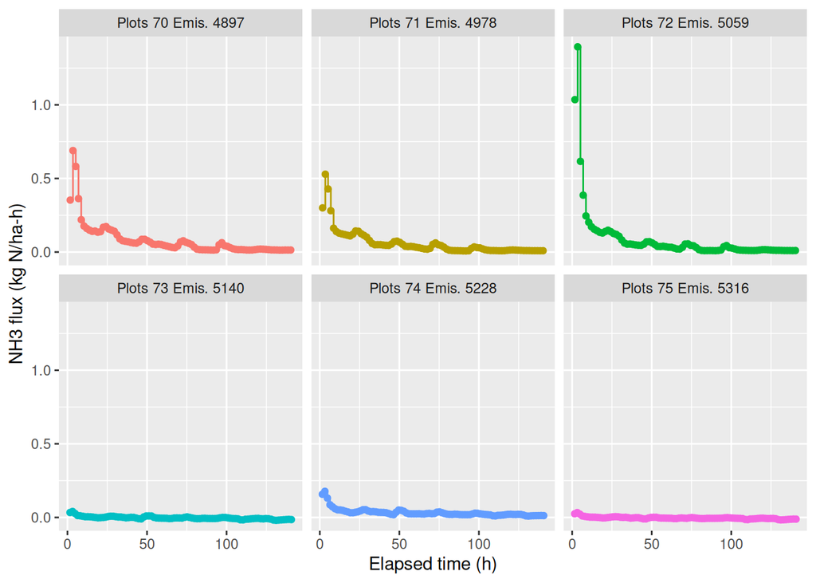

[14 more figures not shown]

## Weather data

[figure not shown]

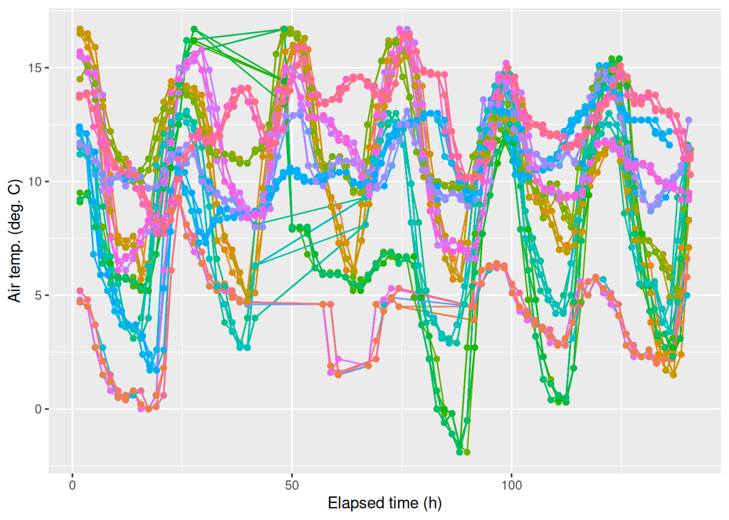

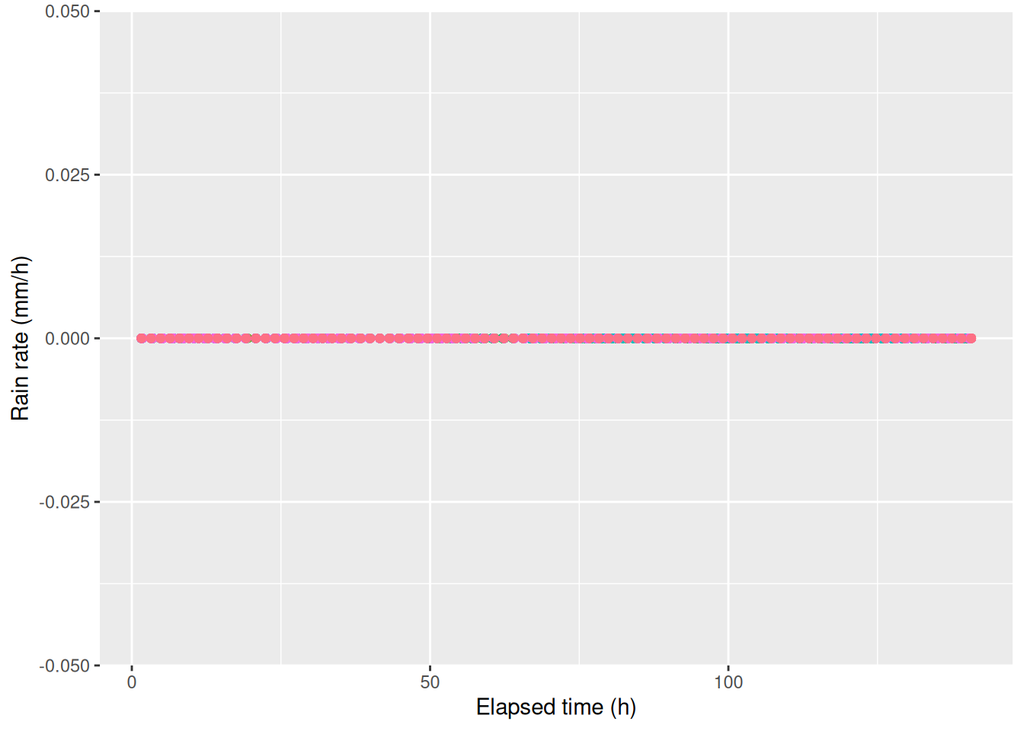

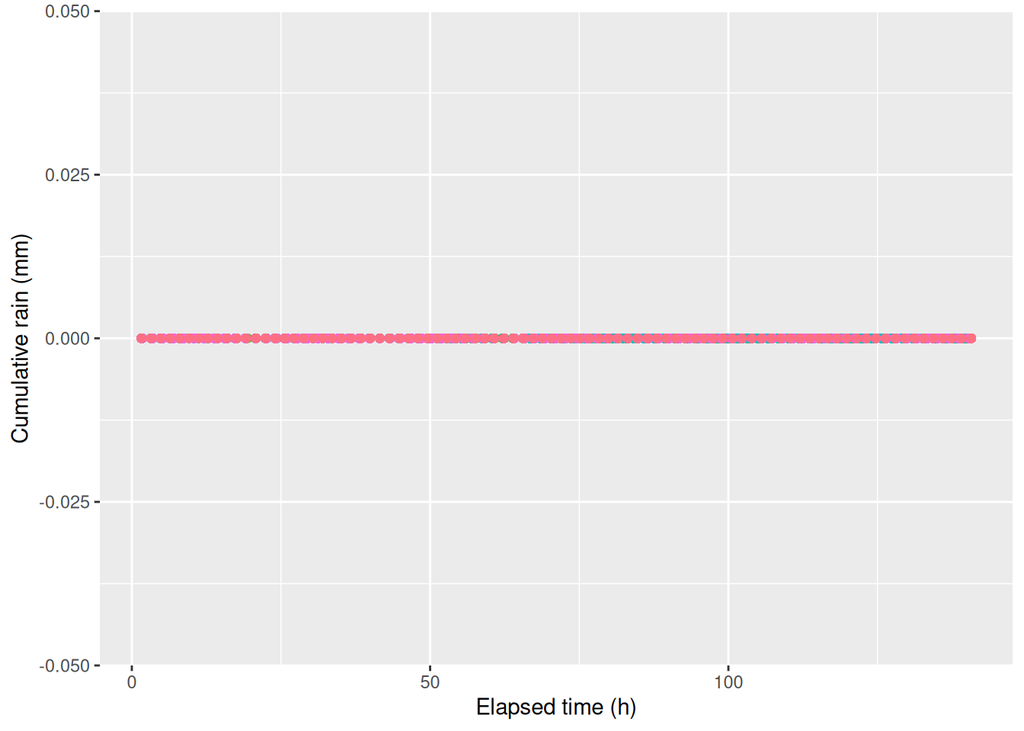

## Manure and application

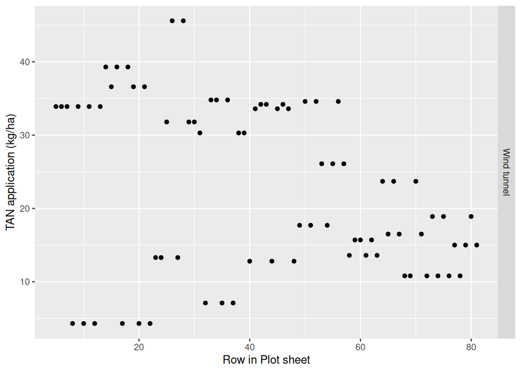

# 10. `dfsumm` summary

## Plot-level data

```
##
##  77 rows and 214 columns
##  77 unique rows
##                     pub.id      proj     exper
## Class              logical character character
## Minimum               <NA>  STABIL26         1
## Maximum               <NA>  STABIL26         9
## Mean                  <NA>      <NA>      <NA>
## Unique (excld. NA)       0         1         9
## Missing values          77         0         0
## Sorted                <NA>      TRUE      TRUE
##
##                                                                                                                                                                                         cpmid
## Class                                                                                                                                                                               character
## Minimum                    D:1.I:AU.Pr:STABIL26.F:../../data-submitted/03/AU/ALFAM2_template_8.3_Stabil26.xlsx.E:1.F:Foulumgård.P:1 AD.T:AD.R:1.R2:.T:2022-04-05 14:17:02.544.M:Wind tunnelNA
## Maximum            D:1.I:AU.Pr:STABIL26.F:../../data-submitted/03/AU/ALFAM2_template_8.3_Stabil26.xlsx.E:9.F:Foulumgård.P:9 PS-LB1.T:PS-LB1.R:2.R2:.T:2022-10-25 11:28:52.549.M:Wind tunnelNA
## Mean                                                                                                                                                                                     <NA>
## Unique (excld. NA)                                                                                                                                                                         77
## Missing values                                                                                                                                                                              0
## Sorted                                                                                                                                                                                   TRUE
##
##                         field      plot       rep plot.area     lat    long
## Class               character character character   numeric numeric numeric
## Minimum            Foulumgård      1 AD         1       0.2    56.5    9.56
## Maximum            Foulumgård  9 PS-LB1         3       0.2    56.5    9.56
## Mean                     <NA>      <NA>      <NA>       0.2    56.5    9.56
## Unique (excld. NA)          1        59         3         1       1       1
## Missing values              0         0         0         0       0       0
## Sorted                   TRUE     FALSE     FALSE      TRUE    TRUE    TRUE
##
##                      country      topo soil.samp.z    clay    silt    sand
## Class              character character   character numeric numeric numeric
## Minimum                   DK      flat         0-5       9      24      65
## Maximum                   DK      flat         0-5       9      24      65
## Mean                    <NA>      <NA>        <NA>       9      24      65
## Unique (excld. NA)         1         1           1       1       1       1
## Missing values             0         0           0       0       0       0
## Sorted                  TRUE      TRUE        TRUE    TRUE    TRUE    TRUE
##
##                         oc soil.type soil.water soil.water.v soil.moist
```

[output cut: 362 more lines]

```
## Maximum            Band spread or trailing hose        <NA>             Pig
## Mean                                       <NA>        <NA>            <NA>
## Unique (excld. NA)                            1           0               2
## Missing values                                0          77               0
## Sorted                                     TRUE        <NA>           FALSE
##
##                    date.start
## Class                    Date
## Minimum            2022-04-05
## Maximum            2022-10-25
## Mean                     <NA>
## Unique (excld. NA)          9
## Missing values              0
## Sorted                  FALSE
##
```

## Interval-level emission data

```
##
##  5927 rows and 140 columns
##  5927 unique rows
##                                                                                                                                                                                         cpmid
## Class                                                                                                                                                                               character
## Minimum                    D:1.I:AU.Pr:STABIL26.F:../../data-submitted/03/AU/ALFAM2_template_8.3_Stabil26.xlsx.E:1.F:Foulumgård.P:1 AD.T:AD.R:1.R2:.T:2022-04-05 14:17:02.544.M:Wind tunnelNA
## Maximum            D:1.I:AU.Pr:STABIL26.F:../../data-submitted/03/AU/ALFAM2_template_8.3_Stabil26.xlsx.E:9.F:Foulumgård.P:9 PS-LB1.T:PS-LB1.R:2.R2:.T:2022-10-25 11:28:52.549.M:Wind tunnelNA
## Mean                                                                                                                                                                                     <NA>
## Unique (excld. NA)                                                                                                                                                                         77
## Missing values                                                                                                                                                                              0
## Sorted                                                                                                                                                                                   TRUE
##
##                     pub.id      proj     exper      field      plot       rep
## Class              logical character character  character character character
## Minimum               <NA>  STABIL26         1 Foulumgård      1 AD         1
## Maximum               <NA>  STABIL26         9 Foulumgård  9 PS-LB1         3
## Mean                  <NA>      <NA>      <NA>       <NA>      <NA>      <NA>
## Unique (excld. NA)       0         1         9          1        59         3
## Missing values        5927         0         0          0         0         0
## Sorted                <NA>      TRUE      TRUE       TRUE     FALSE     FALSE
##
##                        treat   meas.tech meas.tech.det plot.area     lat
## Class              character   character       logical   numeric numeric
## Minimum                   AD Wind tunnel          <NA>       0.2    56.5
## Maximum               PS-LB2 Wind tunnel          <NA>       0.2    56.5
## Mean                    <NA>        <NA>          <NA>       0.2    56.5
## Unique (excld. NA)        11           1             0         1       1
## Missing values             0           0          5927         0       0
## Sorted                 FALSE        TRUE          <NA>      TRUE    TRUE
##
##                       long   country      topo soil.samp.z    clay    silt
## Class              numeric character character   character numeric numeric
## Minimum               9.56        DK      flat         0-5       9      24
## Maximum               9.56        DK      flat         0-5       9      24
## Mean                  9.56      <NA>      <NA>        <NA>       9      24
## Unique (excld. NA)       1         1         1           1       1       1
## Missing values           0         0         0           0       0       0
## Sorted                TRUE      TRUE      TRUE        TRUE    TRUE    TRUE
##
##                       sand      oc soil.type soil.water soil.water.v soil.moist
```

[output cut: 245 more lines]

```
## Maximum                        Pig 2022-04-05          5840       81
## Mean                          <NA>       <NA>          2930     44.6
## Unique (excld. NA)               2          1            77       77
## Missing values                   0          0             0        0
## Sorted                       FALSE       TRUE          TRUE     TRUE
##
##                             first.rows ggplotgroup
## Class                           factor      factor
## Minimum             Plots 10 Emis. 298 (4.92,10.8]
## Maximum              Plots 9 Emis. 239 (75.2,81.1]
## Mean               Plots 49 Emis. 3159 (40.1,45.9]
## Unique (excld. NA)                  77          13
## Missing values                       0           0
## Sorted                           FALSE        TRUE
##
```